# Border Crossings R Notebook

This notebook explores border crossing data from the Bureau of Transportation Statistics. Each “crossing” is an **entry** into the United States from Mexico or Canada.

Data downloaded from https://data.transportation.gov/Research-and-Statistics/Border-Crossing-Entry-Data/keg4-3bc2/data on Feb. 16, 2019.

Initial data cleaning in Excel involved parsing three data points (State, Latitude and Longitude) from a single column (Location) into three columns using the =clean() and text-to-columns functions. The date column was reformated as yyyy-mm-dd. Some variables names were shortened.

The resulting compressed CSV datafile is at https://github.com/gregmunno/mnd-border/blob/master/crossings.zip.

To import the data from an R Project folder and look at he first lines of data:

```r
install.packages("tidyverse", repos = "http://cran.us.r-project.org")
library("readr")
crossings <- read_csv("data-raw/crossings.zip")
head(crossings)
```

[output not shown]

We can quickly summarize all columns.

```r
install.packages("summarytools", repos = "http://cran.us.r-project.org")
library("summarytools")
library("tidyverse")
dfSummary(crossings)
```

```
## Data Frame Summary
## crossings
## N: 341989
## ------------------------------------------------------------------------------------------------------------------------------------------
## No   Variable         Stats / Values                      Freqs (% of Valid)      Text Graph                           Valid     Missing
## ---- ---------------- ----------------------------------- ----------------------- ------------------------------------ --------- ---------
## 1    port             1. Eastport                         5427 ( 1.6%)                                                 341989    0
##      [character]      2. Buffalo-Niagara Falls            3276 ( 1.0%)                                                 (100%)    (0%)
##                       3. Calais                           3276 ( 1.0%)
##                       4. Calexico East                    3276 ( 1.0%)
##                       5. Champlain-Rouses Point           3276 ( 1.0%)
##                       6. El Paso                          3276 ( 1.0%)
##                       7. Jackman                          3276 ( 1.0%)
##                       8. Nogales                          3276 ( 1.0%)
##                       9. Portal                           3276 ( 1.0%)
##                       10. Sumas                           3276 ( 1.0%)
##                       [ 106 others ]                      307078 (89.8%)          IIIIIIIIIIIIIIII
##
## 2    state            1. NORTH DAKOTA                     56386 (16.5%)           IIIIIIIIIIIIIIII                     341989    0
##      [character]      2. WASHINGTON                       44064 (12.9%)           IIIIIIIIIIII                         (100%)    (0%)
##                       3. MONTANA                          37745 (11.0%)           IIIIIIIIII
##                       4. MAINE                            37611 (11.0%)           IIIIIIIIII
##                       5. TEXAS                            35206 (10.3%)           IIIIIIIII
##                       6. MINNESOTA                        22833 ( 6.7%)           IIIIII
##                       7. NEW YORK                         20363 ( 6.0%)           IIIII
##                       8. ARIZONA                          18982 ( 5.6%)           IIIII
##                       9. CALIFORNIA                       18856 ( 5.5%)           IIIII
##                       10. VERMONT                         15991 ( 4.7%)           IIII
##                       [ 5 others ]                        33952 ( 9.9%)           IIIIIIIII
##
## 3    state.abbrev     1. ND                               56386 (16.5%)           IIIIIIIIIIIIIIII                     341989    0
##      [character]      2. WA                               44064 (12.9%)           IIIIIIIIIIII                         (100%)    (0%)
##                       3. MT                               37745 (11.0%)           IIIIIIIIII
##                       4. ME                               37611 (11.0%)           IIIIIIIIII
##                       5. TX                               35206 (10.3%)           IIIIIIIII
##                       6. MN                               22833 ( 6.7%)           IIIIII
##                       7. NY                               20363 ( 6.0%)           IIIII
##                       8. AZ                               18982 ( 5.6%)           IIIII
##                       9. CA                               18856 ( 5.5%)           IIIII
##                       10. VT                              15991 ( 4.7%)           IIII
```

[output cut: 32 more lines]

```
##                       IQR (CV) : 2429 (5.41)                                      :
##                                                                                   :
##
## 9    latitude         mean (sd) : 44.07 (8.12)            165 distinct values                 :                        341989    0
##      [numeric]        min < med < max :                                                       :                        (100%)    (0%)
##                       25.89 < 48.54 < 63.34                                                   :
##                       IQR (CV) : 6.09 (0.18)                                        .       : :
##                                                                                   : :     . : :
##
## 10   longitude        mean (sd) : -99.91 (18.24)          221 distinct values               :                          341989    0
##      [numeric]        min < med < max :                                                 :   :       .                  (100%)    (0%)
##                       -142.99 < -101.63 < -66.98                                        : : :       :
##                       IQR (CV) : 25.14 (-0.18)                                          : : : .     :
##                                                                                   . . : : : : : : : :
## ------------------------------------------------------------------------------------------------------------------------------------------
```

Not all of these results are intresting or meaningful, but the output shows that:

**A.** There are no missing values in any of the 341,989 observations (cases/rows) across all 10 of the variables.

**B.** The date variable covers 273 unique time periods from Jan. 1, 1996 to Sept. 1, 2018.

**C.** There are more ports of entry on the northern border than the southern, with the most in North Dakota.

The most interesting variable in the dataset is probably “num.crossings” the number of entries into the country. We examine this in relation to the northern and southern border (which has more crossings), each state, each crossing, each crossing type (i.e. vehicle vs. train), and each year.

**Crossings (entries) by Border**

```r
crossings %>%
  group_by(border) %>%
  summarise(
    ave.crossing = mean(num.crossings),
    total.crossings = sum(num.crossings)
    ) %>%
  mutate_each(funs(prettyNum(., big.mark=",")))
```

[output not shown]

```
## `mutate_each()` is deprecated.
## Use `mutate_all()`, `mutate_at()` or `mutate_if()` instead.
## To map `funs` over all variables, use `mutate_all()`
```

Despite having more crossing points along the longer northern boarder, **72 percent** of entries in the time period examined here were from Mexico into the United States.

```r
(6947271285/9595497006)*100
```

```
## [1] 72.40137
```

**Crossings (entries) by Crossing Type**

```r
crossings %>%
  group_by(cross.type) %>%
  summarise(
    ave.crossing = mean(num.crossings),
    total.crossings = sum(num.crossings)
  ) %>%
  arrange(desc(total.crossings)) %>%
  mutate_each(funs(prettyNum(., big.mark=",")))
```

[output not shown]

```
## `mutate_each()` is deprecated.
## Use `mutate_all()`, `mutate_at()` or `mutate_if()` instead.
## To map `funs` over all variables, use `mutate_all()`
```

Here, it is helpfil to understand the definitions of each crossing type, https://www.bts.gov/browse-statistical-products-and-data/statistical-products/border-crossingdata-entry-coverage

A few findings to hightlight:

**A.** Since 5.37 billion people entered the U.S. in 2.51 billion cars, the average car entering since 1996 had, on average, just over two passengers: [5,366,669,973/2,511,034,848 = 2.137]

**B.** The number of full trucks (173,523,772) plus the number of emtpy (62,509,816) equals 236,033,588, which is not equal to the total trucks number reported here. That descrepency is not addressed in the documentation. It could mean trucks without containers (cab only), or that some crossings do not make the empty/full distinction. Regardless, it requires more explanation.

**C.** Pedistrian crossings are fairly common over this 20+ year time period and outnumber train and bus crossings combined.

**By Date**

```r
crossings %>%
  group_by(date) %>%
  summarise(
    ave.crossings = mean(num.crossings)
  ) %>%
  arrange(desc(ave.crossings))
```

[output not shown]

It will be easier to see trends by year rather than date so we’ll parse out year from date

```r
library("lubridate")
crossings_year <- crossings %>%
  mutate(year = year(date),
         month = month(date),
         day = day(date)
         )
head(crossings_year)
```

[output not shown]

```r
crossings_year %>%
  group_by(year) %>%
  summarise(
    total.crossings = sum(num.crossings)
  )
```

[output not shown]

```r
library("ggplot2")
```

```r
total_by_year <- crossings_year %>%
  group_by(year) %>%
  summarise(
    total.crossings = sum(num.crossings)
  )
```

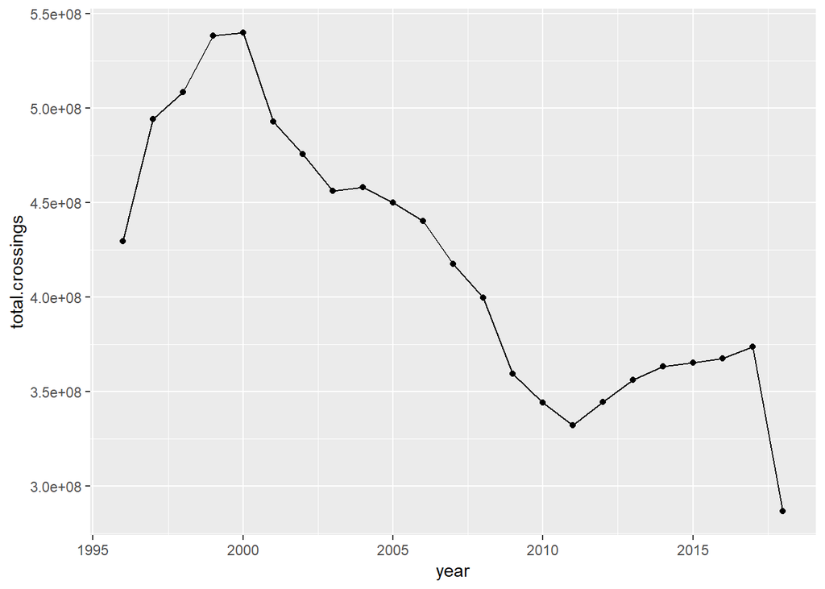

```r
ggplot(data = total_by_year, mapping = aes(x=year, y=total.crossings, group=1)) +
  geom_line()+
  geom_point()
```